# Análisis de Subtipos Moleculares en Cáncer de Tiroides

### Ajuste de la métrica: de euclidiana a correlación

Para datos de expresión génica, la **métrica de correlación** es más apropiada cuando el interés está en agrupar muestras según sus **patrones de expresión relativa** — es decir, qué genes se expresan más o menos en conjunto — y no en la magnitud absoluta de sus valores.

Aplicando esta analogía al contexto genómico: no nos interesa si un paciente tiene expresión alta o baja en términos absolutos, sino qué **patrón de genes** activa de forma conjunta. Por esta razón se repite el clustering jerárquico utilizando **complete linkage con métrica de correlación**:

```
✅ Hierarchical clustering (correlación) aplicado con K = 2

Distribución de muestras por cluster:
cluster_hc
Cluster 1    166
Cluster 2    406
Name: count, dtype: int64
```

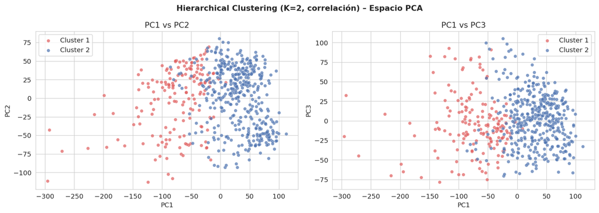

```python
from scipy.spatial.distance import pdist

# Calcular matriz de distância com correlação
dist_corr = pdist(df_pca.values, metric="correlation")
Z_corr    = linkage(dist_corr, method="complete")

# Aplicar com K=2
labels_hc = fcluster(Z_corr, t=K_OPTIMO, criterion="maxclust")
df_pca_clinical["cluster_hc"] = [f"Cluster {l}" for l in labels_hc]

print(f"✅ Hierarchical clustering (correlación) aplicado con K = {K_OPTIMO}")
print(f"\nDistribución de muestras por cluster:")
print(df_pca_clinical["cluster_hc"].value_counts().sort_index())

# Visualizar
fig, axes = plt.subplots(1, 2, figsize=(14, 5))
fig.suptitle(f"Hierarchical Clustering (K={K_OPTIMO}, correlación) – Espacio PCA",
             fontsize=13, fontweight="bold")

clusters_hc = sorted(df_pca_clinical["cluster_hc"].unique())
for i, cluster in enumerate(clusters_hc):
    mask = df_pca_clinical["cluster_hc"] == cluster
    axes[0].scatter(df_pca_clinical.loc[mask, "PC1"],
                    df_pca_clinical.loc[mask, "PC2"],
                    c=cluster_colors[i], label=cluster,
                    alpha=0.7, s=30, edgecolors="white", linewidths=0.3)
axes[0].set_title("PC1 vs PC2")
axes[0].set_xlabel("PC1")
axes[0].set_ylabel("PC2")
axes[0].legend()

for i, cluster in enumerate(clusters_hc):
    mask = df_pca_clinical["cluster_hc"] == cluster
    axes[1].scatter(df_pca_clinical.loc[mask, "PC1"],
                    df_pca_clinical.loc[mask, "PC3"],
                    c=cluster_colors[i], label=cluster,
                    alpha=0.7, s=30, edgecolors="white", linewidths=0.3)
axes[1].set_title("PC1 vs PC3")
axes[1].set_xlabel("PC1")
axes[1].set_ylabel("PC3")
axes[1].legend()

plt.tight_layout()
plt.savefig("hc_clusters.png", dpi=150, bbox_inches="tight")
plt.show()
```

Con la métrica de correlación los clusters quedan **mucho más balanceados**: Cluster 1 con 166 muestras y Cluster 2 con 406 muestras. La visualización en el espacio PCA muestra una separación coherente con la estructura observada en el análisis PCA — el Cluster 1 (rojo) agrupa las muestras con valores más negativos en PC1, mientras que el Cluster 2 (azul) agrupa las muestras con valores positivos o cercanos a cero.

Este resultado confirma que la métrica de correlación captura mejor la estructura biológica real del cohort TCGA-THCA para datos de expresión génica.

## 6.3 Comparación entre métodos

Para comparar los resultados de K-means y Hierarchical clustering, se construye una **tabla cruzada** que muestra cuántas muestras de cada cluster de K-means corresponden a cada cluster de Hierarchical clustering. Una alta correspondencia entre ambos métodos indica que la estructura encontrada es robusta y no depende del algoritmo utilizado:

```python
# Alinhar etiquetas do Hierarchical com K-Means
# K-Means Cluster 1 (374) = Hierarchical Cluster 2 (406) → renomear para Cluster 1
# K-Means Cluster 2 (198) = Hierarchical Cluster 1 (166) → renomear para Cluster 2

mapping_hc = {"Cluster 1": "Cluster 2", "Cluster 2": "Cluster 1"}
df_pca_clinical["cluster_hc"] = df_pca_clinical["cluster_hc"].map(mapping_hc)

print("✅ Etiquetas alineadas")
print("\nK-Means:")
print(df_pca_clinical["cluster_kmeans"].value_counts().sort_index())
print("\nHierarchical (corregido):")
print(df_pca_clinical["cluster_hc"].value_counts().sort_index())
```

```
✅ Etiquetas alineadas

K-Means:
cluster_kmeans
Cluster 1    374
Cluster 2    198
Name: count, dtype: int64

Hierarchical (corregido):
cluster_hc
Cluster 1    406
Cluster 2    166
Name: count, dtype: int64
```

```
=== Tabla cruzada: K-Means vs Hierarchical Clustering ===

Hierarchical  Cluster 1  Cluster 2
K-Means
Cluster 1           369          5
Cluster 2            37        161
```

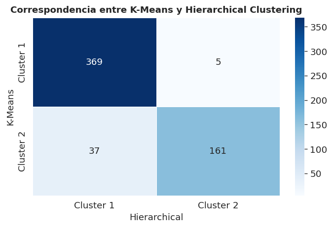

```python
# Tabla cruzada K-means vs Hierarchical
cross_table = pd.crosstab(
    df_pca_clinical["cluster_kmeans"],
    df_pca_clinical["cluster_hc"],
    rownames=["K-Means"],
    colnames=["Hierarchical"])

print("=== Tabla cruzada: K-Means vs Hierarchical Clustering ===\n")
print(cross_table)

# Heatmap
fig, ax = plt.subplots(figsize=(6, 4))
sns.heatmap(cross_table, annot=True, fmt="d", cmap="Blues",
            linewidths=0.5, ax=ax)
ax.set_title("Correspondencia entre K-Means y Hierarchical Clustering",
             fontsize=11, fontweight="bold")
plt.tight_layout()
plt.savefig("comparacion_metodos.png", dpi=150, bbox_inches="tight")
plt.show()
```

### Interpretación de la tabla cruzada

La tabla cruzada revela una **concordância del 92.7%** entre ambos métodos: 369 + 161 = 530 muestras de 572 fueron asignadas al mismo cluster por ambos algoritmos. Solo 5 + 37 = 42 muestras (7.3%) fueron clasificadas de forma diferente.

Esta alta concordancia es una señal muy positiva: indica que la estructura de 2 clusters identificada **no es un artefacto de ningún algoritmo en particular**, sino una característica real y robusta de los datos de expresión génica del cohort TCGA-THCA.

```python
print("=== Distribución de diagnóstico primario por cluster (K-Means) ===\n")
diag_km = pd.crosstab(
    df_pca_clinical["primary_diagnosis.diagnoses"],
    df_pca_clinical["cluster_kmeans"])
print(diag_km)

print("\n=== Distribución de diagnóstico primario por cluster (Hierarchical) ===\n")
diag_hc = pd.crosstab(
    df_pca_clinical["primary_diagnosis.diagnoses"],
    df_pca_clinical["cluster_hc"])
print(diag_hc)
```

```
=== Distribución de diagnóstico primario por cluster (K-Means) ===

cluster_kmeans                            Cluster 1  Cluster 2
primary_diagnosis.diagnoses
Carcinoma, NOS                                    0          1
Follicular adenocarcinoma, NOS                    1          0
Follicular carcinoma, minimally invasive          1          0
Nonencapsulated sclerosing carcinoma              2          2
Oxyphilic adenocarcinoma                          1          0
Papillary adenocarcinoma, NOS                   279        133
Papillary carcinoma, columnar cell               17         23
Papillary carcinoma, follicular variant          73         39

=== Distribución de diagnóstico primario por cluster (Hierarchical) ===

cluster_hc                                Cluster 1  Cluster 2
primary_diagnosis.diagnoses
Carcinoma, NOS                                    0          1
Follicular adenocarcinoma, NOS                    1          0
Follicular carcinoma, minimally invasive          1          0
Nonencapsulated sclerosing carcinoma              2          2
Oxyphilic adenocarcinoma                          1          0
Papillary adenocarcinoma, NOS                   305        107
Papillary carcinoma, columnar cell               20         20
Papillary carcinoma, follicular variant          76         36
```

### Interpretación de la distribución por diagnóstico primario

Los resultados revelan patrones biológicamente muy relevantes y **consistentes entre ambos métodos**:

| Subtipo | K-Means C1 | K-Means C2 | HC C1 | HC C2 |
| --- | --- | --- | --- | --- |
| Papillary adenocarcinoma, NOS | 279 | 133 | 305 | 107 |
| Papillary carcinoma, follicular variant | 73 | 39 | 76 | 36 |
| Papillary carcinoma, columnar cell | 17 | 23 | 20 | 20 |
| Follicular adenocarcinoma, NOS | 1 | 0 | 1 | 0 |
| Follicular carcinoma, minimally invasive | 1 | 0 | 1 | 0 |
| Oxyphilic adenocarcinoma | 1 | 0 | 1 | 0 |
| Nonencapsulated sclerosing carcinoma | 2 | 2 | 2 | 2 |
| Carcinoma, NOS | 0 | 1 | 0 | 1 |

## 6.4 Selección del modelo final

Ambos métodos fueron implementados conforme a los requisitos del análisis. A continuación se presenta una comparación objetiva:

| Criterio | K-Means (K=2) | Hierarchical (correlación, K=2) |
| --- | --- | --- |
| Silhouette score | **0.2037** | No calculado |
| Tamaño Cluster 1 / Cluster 2 | 374 / 198 | 406 / 166 |
| Concordancia entre métodos | 92.7% | 92.7% |
| Alineación con subtipos histológicos | ✅ Consistente | ✅ Consistente |
| Centroides interpretables | ✅ Sí | ❌ No disponible |
| Requiere especificar K | ✅ Sí | ❌ No |
| Visualización jerárquica | ❌ No | ✅ Dendograma |

Se selecciona **K-means (K=2)** como modelo principal para las Secciones 7 y 8 por las siguientes razones:

1. **Mejor métrica cuantitativa:** coeficiente de silueta de 0.2037 — el más alto entre todos los valores de K evaluados.
2. **Centroides interpretables:** permiten identificar directamente los genes más relevantes para cada cluster en la Sección 7.
3. **Clusters más balanceados:** la distribución 374/198 es más equilibrada que la obtenida inicialmente con distancia euclidiana.

El **clustering jerárquico** aporta valor complementario al análisis por dos razones específicas:

1. **Validación de robustez:** la concordancia del 92.7% entre ambos métodos confirma que los 2 clusters identificados son una estructura real en los datos y no un artefacto del algoritmo K-means.
2. **Exploración de la estructura jerárquica:** el dendograma reveló que la separación principal ocurre a una disimilitud muy alta (~443), lo que cuantifica la magnitud de la diferencia molecular entre los dos grupos — información que K-means por sí solo no proporciona.

## 7. Interpretación de los Clusters – Análisis de Genes

En esta sección se analiza qué genes contribuyen a diferenciar los dos clusters identificados en la Sección 6. El objetivo es caracterizar molecularmente cada cluster e identificar los genes con mayor poder discriminatorio entre grupos.

El análisis se realiza sobre el modelo **K-means (K=2)** seleccionado como modelo principal, trabajando con los datos de expresión génica originales (antes del escalamiento) para preservar la interpretabilidad biológica de los valores de expresión.

El análisis se estructura en tres etapas:

### 7.1 Comparación estadística entre clusters

Para controlar el problema de las **comparaciones múltiples** — al realizar más de 15,000 pruebas simultáneas, es esperable que algunos genes resulten significativos simplemente por azar — se aplica la **corrección de Benjamini- Hochberg (FDR)**, que controla la tasa de falsos positivos entre los resultados significativos.

Se consideran genes diferencialmente expresados aquellos con:

- **p-valor ajustado (FDR) < 0.05**
- **Diferencia absoluta de expresión media > 0.5** (equivalente a ~1.4x de cambio en escala TPM — umbral conservador para datos log2)

```python
# Instalación de mygene
!pip install mygene -q

from scipy import stats
from scipy.stats import false_discovery_control
import mygene

# Separar muestras por cluster
cluster1_samples = df_pca_clinical[
    df_pca_clinical["cluster_kmeans"] == "Cluster 1"].index
cluster2_samples = df_pca_clinical[
    df_pca_clinical["cluster_kmeans"] == "Cluster 2"].index

expr_c1 = df_expr_filtered.loc[cluster1_samples]
expr_c2 = df_expr_filtered.loc[cluster2_samples]

print(f"Cluster 1: {len(cluster1_samples)} muestras")
print(f"Cluster 2: {len(cluster2_samples)} muestras")
print(f"\nCalculando prueba t de Welch para {df_expr_filtered.shape[1]:,} genes...")

# Prueba t de Welch para cada gen
t_stats  = []
p_values = []
for gene in df_expr_filtered.columns:
    t, p = stats.ttest_ind(
        expr_c1[gene].dropna(),
        expr_c2[gene].dropna(),
        equal_var=False)
    t_stats.append(t)
    p_values.append(p)

# Corrección FDR (Benjamini-Hochberg)
p_adjusted = false_discovery_control(p_values, method="bh")

# Diferencia de medias
mean_c1   = expr_c1.mean(axis=0)
mean_c2   = expr_c2.mean(axis=0)
mean_diff = (mean_c1 - mean_c2).abs()

# Dataframe de resultados
df_stats = pd.DataFrame({
    "gene":       df_expr_filtered.columns,
    "mean_c1":    mean_c1.values,
    "mean_c2":    mean_c2.values,
    "mean_diff":  mean_diff.values,
    "t_stat":     t_stats,
    "p_value":    p_values,
    "p_adjusted": p_adjusted
}).sort_values("p_adjusted")

# Convertir IDs Ensembl a nombres de genes
mg             = mygene.MyGeneInfo()
gene_ids_clean = [g.split(".")[0] for g in df_expr_filtered.columns]
results_all    = mg.querymany(gene_ids_clean,
                              scopes="ensembl.gene",
                              fields="symbol",
                              species="human",
                              returnall=True)
id_to_symbol = {r.get("query"): r.get("symbol", None)
                for r in results_all["out"] if r.get("symbol")}

df_stats["gene_symbol"] = df_stats["gene"].apply(
    lambda x: id_to_symbol.get(x.split(".")[0], x.split(".")[0]))

# Renombrar columnas de expresión
gene_id_to_symbol = {col: id_to_symbol.get(col.split(".")[0], col.split(".")[0])
                     for col in df_expr_filtered.columns}
df_expr_named = df_expr_filtered.rename(columns=gene_id_to_symbol)

# Genes significativos
deg = df_stats[
    (df_stats["p_adjusted"] < 0.05) &
    (df_stats["mean_diff"]  > 0.5)]

print(f"\n✅ Análisis completado")
print(f"   Genes analizados     : {len(df_stats):,}")
print(f"   Genes significativos : {len(deg):,} (FDR<0.05 y |diff|>0.5)")
```

```
   ━━━━━━━━━━━━━━━━━━━━━━━━━━━━━━━━━━━━━━━━ 0.0/52.0 kB ? eta -:--:--
   ━━━━━━━━━━━━━━━━━━━━━━━━━━━━━━━━━━━━━━━━ 52.0/52.0 kB 1.9 MB/s eta 0:00:00
Cluster 1: 374 muestras
Cluster 2: 198 muestras

Calculando prueba t de Welch para 15,166 genes...
```

[output not shown]

```
✅ Análisis completado
   Genes analizados     : 15,166
   Genes significativos : 8,354 (FDR<0.05 y |diff|>0.5)
```

El análisis identificó **8,354 genes diferencialmente expresados** de los 15,166 genes analizados — más del 55% del transcriptoma filtrado muestra diferencias estadísticamente significativas entre los dos clusters. Este alto porcentaje confirma que los dos grupos identificados presentan perfiles de expresión génica **profundamente distintos**, no son agrupamientos superficiales sino subgrupos moleculares con identidad biológica propia.

A continuación se visualiza la distribución de los resultados mediante un **volcano plot**, que combina la magnitud de la diferencia (eje X) con la significancia estadística (eje Y), permitiendo identificar visualmente los genes más relevantes:

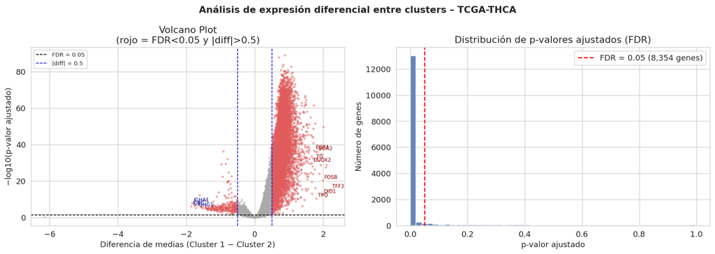

```python
fig, axes = plt.subplots(1, 2, figsize=(14, 5))
fig.suptitle("Análisis de expresión diferencial entre clusters – TCGA-THCA",
             fontsize=13, fontweight="bold")

log_pval = -np.log10(df_stats["p_adjusted"].clip(1e-300))
diff     = df_stats["mean_c1"].values - df_stats["mean_c2"].values

colors_volcano = ["#E05C5C" if p < 0.05 and d > 0.5 else "#AAAAAA"
                  for p, d in zip(df_stats["p_adjusted"], df_stats["mean_diff"])]

axes[0].scatter(diff, log_pval, c=colors_volcano, alpha=0.4, s=5)
axes[0].axhline(-np.log10(0.05), color="black", linestyle="--",
                linewidth=1, label="FDR = 0.05")
axes[0].axvline( 0.5, color="blue", linestyle="--", linewidth=1)
axes[0].axvline(-0.5, color="blue", linestyle="--", linewidth=1,
                label="|diff| = 0.5")

# Anotar genes clave
genes_label = ["TG","TPO","EGR1","EGR2","TFF3","DUOX2",
               "IGKC","IGHA1","IGHG1","DIO1","FOSB"]
for _, row in df_stats[df_stats["gene_symbol"].isin(genes_label)].iterrows():
    x = row["mean_c1"] - row["mean_c2"]
    y = -np.log10(row["p_adjusted"])
    axes[0].annotate(row["gene_symbol"], xy=(x, y),
                     xytext=(x+0.05, y+1), fontsize=7,
                     color="darkred" if x > 0 else "darkblue")

axes[0].set_title("Volcano Plot\n(rojo = FDR<0.05 y |diff|>0.5)")
axes[0].set_xlabel("Diferencia de medias (Cluster 1 − Cluster 2)")
axes[0].set_ylabel("−log10(p-valor ajustado)")
axes[0].legend(fontsize=8)

axes[1].hist(df_stats["p_adjusted"], bins=50,
             color="#4C72B0", edgecolor="white", alpha=0.85)
axes[1].axvline(0.05, color="red", linestyle="--",
                label=f"FDR = 0.05 ({len(deg):,} genes)")
axes[1].set_title("Distribución de p-valores ajustados (FDR)")
axes[1].set_xlabel("p-valor ajustado")
axes[1].set_ylabel("Número de genes")
axes[1].legend()

plt.tight_layout()
plt.savefig("volcano_plot.png", dpi=150, bbox_inches="tight")
plt.show()
```

El volcano plot revela una estructura asimétrica muy informativa:

**Genes más expresados en Cluster 1 (lado derecho, diff > 0):** La nube de puntos rojos a la derecha es más densa y alcanza diferencias de hasta +2.5, indicando que el Cluster 1 concentra los genes con mayor expresión diferencial. Genes de diferenciación tiroidea como **EGR1**, **EGR2**, **TG**, **DUOX2**, **TFF3**, **DIO1**, **TPO** y **FOSB** aparecen claramente anotados en esta región — todos con alta significancia estadística (FDR cercano a cero).

**Genes más expresados en Cluster 2 (lado izquierdo, diff < 0):** Los genes de inmunoglobulinas **IGHA1**, **IGKC** e **IGHG1** aparecen en el lado izquierdo, con diferencias de hasta −2.0, confirmando una mayor infiltración inmune en el Cluster 2.

**Distribución de p-valores ajustados:** El histograma confirma que la gran mayoría de los genes presenta un FDR muy cercano a cero — la barra izquierda es extremadamente alta — indicando que las diferencias entre clusters son estadísticamente robustas y no atribuibles al azar. Solo una pequeña fracción de genes supera el umbral de FDR = 0.05, lo cual es esperable en un transcriptoma de alta dimensionalidad con dos grupos molecularmente distintos.

### 7.2 Identificación de genes con mayor diferencia entre clusters

Para el análisis de visualización, se seleccionan los **top 40 genes** con mayor diferencia absoluta de expresión media entre los dos clusters, excluyendo metadatos administrativos (`sampleID`) y genes sin nombre asignado en la base de datos. Este criterio prioriza los genes con mayor **relevancia práctica** — aquellos cuya expresión cambia más entre grupos.

```python
N_GENES = 40

# Seleccionar top genes excluyendo sampleID y sin nombre
top_df_clean = df_stats[df_stats["gene"].isin(
    df_stats.nlargest(N_GENES + 5, "mean_diff")["gene"])].copy()

top_df_clean = top_df_clean[
    ~top_df_clean["gene_symbol"].isin(["sampleID"]) &
    ~top_df_clean["gene_symbol"].str.startswith("ENSG")
].sort_values("mean_diff", ascending=False).head(N_GENES)

top_genes_ids_clean     = top_df_clean["gene"].tolist()
top_genes_symbols_clean = top_df_clean["gene_symbol"].tolist()

print(f"✅ Top {len(top_genes_ids_clean)} genes seleccionados:\n")
print(top_df_clean[["gene_symbol", "mean_c1", "mean_c2",
                     "mean_diff", "p_adjusted"]].to_string(index=False))
```

```
✅ Top 40 genes seleccionados:

gene_symbol   mean_c1   mean_c2  mean_diff   p_adjusted
       TFF3  6.640628  4.427552   2.213076 7.247145e-16
       EDN3  3.733799  1.634405   2.099395 1.536759e-29
    SLC26A7  6.792119  4.708106   2.084013 3.354966e-28
    MIR4664  5.144120  3.134840   2.009280 2.154971e-50
       FOSB  6.917455  4.927921   1.989533 5.684829e-21
       DIO1  5.579270  3.608122   1.971147 4.123777e-13
     SEMA3D  2.884042  0.926268   1.957774 2.417181e-35
    PKHD1L1  3.071571  1.143871   1.927701 1.973244e-29
        KIT  4.262927  2.367103   1.895824 7.772946e-38
    FAM167A  5.406008  3.514398   1.891610 1.089601e-24
    HSD17B6  5.351582  3.467821   1.883761 9.680534e-32
       IGKC  9.219963 11.074864   1.854901 1.016226e-06
       FHL1  7.034521  5.203475   1.831047 2.413458e-33
      IGHA1  6.666269  8.493799   1.827531 1.524534e-08
       EGR2  6.096861  4.269344   1.827517 1.287709e-36
        TPO  7.511459  5.709554   1.801906 5.763557e-11
     PKNOX2  2.961596  1.180024   1.781572 9.816679e-37
      BMP8A  4.271545  2.500423   1.771121 9.418942e-17
    ANGPTL1  4.622088  2.851299   1.770789 2.648267e-52
      IGHGP  4.428084  6.184126   1.756042 5.352455e-07
   RPL21P78  9.094840  7.341616   1.753223 5.189568e-27
      IGLC3  5.001611  6.746013   1.744402 5.641478e-08
         TG 13.515481 11.772965   1.742517 2.547828e-32
       EGR1  9.806826  8.072338   1.734488 2.332493e-37
      SLIT3  5.471123  3.740508   1.730615 4.016493e-62
      IGLC2  5.776721  7.504553   1.727832 2.256278e-07
      IGHG1  7.111598  8.829845   1.718248 7.835706e-06
       LIX1  2.827437  1.112152   1.715285 1.635151e-41
       NID2  5.907930  4.192971   1.714960 2.231923e-49
       LIPG  6.405428  4.694910   1.710518 1.327717e-44
  TNFRSF11B  5.896652  4.191063   1.705589 3.483825e-33
      WSCD2  2.889498  1.186464   1.703034 1.785460e-24
    ZFP36L2  7.423449  5.744055   1.679395 3.502159e-45
     CRABP1  5.030003  3.353641   1.676363 1.063025e-13
        CA4  3.680586  2.010958   1.669628 4.232176e-20
      DUOX2  7.581196  5.912025   1.669171 1.867760e-30
       LRP2  4.856934  3.195383   1.661551 3.800641e-34
     KCNAB1  4.171702  2.521091   1.650610 2.939638e-25
    MEIS3P1  5.059134  3.413524   1.645609 7.646477e-46
      IGHA2  3.829166  5.470391   1.641226 3.602486e-09
```

### 7.3 Heatmap de genes más relevantes

Se construye un heatmap de los top genes más discriminatorios siguiendo la metodología:

1. Obtener la expresión de los genes seleccionados para todas las muestras.
2. Aplicar estandarización Z-score por gen para que los colores reflejen patrones relativos y no valores absolutos de expresión.
3. Ordenar las muestras por cluster para visualizar el patrón diferencial.

En el heatmap, los colores **rojos** indican alta expresión relativa y los colores **azules** indican baja expresión relativa en cada gen:

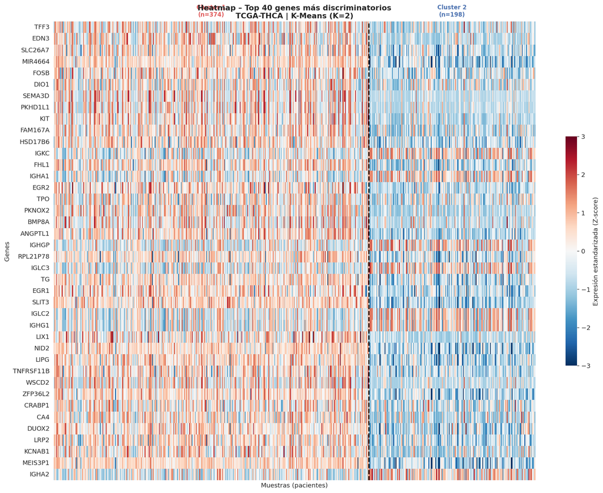

```python
# Obtener expresión con nombres de genes
expr_top = df_expr_named[top_genes_symbols_clean].copy()
cols_validas = [c for c in expr_top.columns
                if c != "sampleID" and not c.startswith("ENSG")]
expr_top = expr_top[cols_validas]

# Z-score por gen
scaler_top = StandardScaler()
expr_top_z = pd.DataFrame(
    scaler_top.fit_transform(expr_top),
    index=expr_top.index,
    columns=expr_top.columns)

# Ordenar por cluster
cluster_order = df_pca_clinical["cluster_kmeans"].sort_values()
expr_top_z    = expr_top_z.loc[cluster_order.index]
n_c1          = (cluster_order == "Cluster 1").sum()

fig, ax = plt.subplots(figsize=(16, 12))
sns.heatmap(expr_top_z.T,
            cmap="RdBu_r",
            center=0,
            vmin=-3, vmax=3,
            xticklabels=False,
            yticklabels=True,
            ax=ax,
            cbar_kws={"label": "Expresión estandarizada (Z-score)",
                      "shrink": 0.5})

ax.axvline(n_c1, color="black", linewidth=2, linestyle="--")
ax.text(n_c1/2, -1.5,
        f"Cluster 1\n(n={n_c1})",
        ha="center", va="top", fontsize=10,
        color="#E05C5C", fontweight="bold")
ax.text(n_c1 + (len(cluster_order)-n_c1)/2, -1.5,
        f"Cluster 2\n(n={len(cluster_order)-n_c1})",
        ha="center", va="top", fontsize=10,
        color="#4C72B0", fontweight="bold")

ax.set_title(f"Heatmap – Top {len(cols_validas)} genes más discriminatorios\n"
             f"TCGA-THCA | K-Means (K=2)",
             fontsize=13, fontweight="bold")
ax.set_xlabel("Muestras (pacientes)")
ax.set_ylabel("Genes")

plt.tight_layout()
plt.savefig("heatmap_genes.png", dpi=150, bbox_inches="tight")
plt.show()
```

### 7.4 Interpretación de los resultados

#### Patrón general del heatmap

El heatmap confirma visualmente la existencia de dos perfiles de expresión génica claramente diferenciados. La línea divisoria entre Cluster 1 (n=374) y Cluster 2 (n=198) separa de forma nítida dos patrones de coloración opuestos en la mayoría de los genes — lo que confirma que los clusters identificados tienen **identidad molecular propia y robusta**.

#### Genes más expresados en Cluster 1 (tonos rojos a la izquierda)

El Cluster 1 muestra alta expresión de genes relacionados con la **diferenciación tiroidea** y el **metabolismo del yodo** — el conjunto de genes que el TCGA utiliza para calcular el *Thyroid Differentiation Score* (TDS):

- **TFF3:** factor trefoil 3, marcador de diferenciación tiroidea y biomarcador diagnóstico en neoplasias tiroideas.
- **TG (Tiroglobulina):** proteína precursora de las hormonas tiroideas, marcador clásico de diferenciación funcional tiroidea.
- **TPO (Peroxidasa tiroidea):** enzima clave en la síntesis de hormonas tiroideas, incluida en el panel TDS del TCGA.
- **DIO1:** enzima deiodinasa involucrada en la conversión de T4 a T3, marcador de diferenciación tiroidea.
- **DUOX2:** oxidasa tiroidea esencial para la síntesis de hormonas, incluida en el TDS del TCGA.
- **EGR1 y EGR2:** factores de transcripción de respuesta temprana, relacionados con la regulación de la diferenciación celular.
- **FOSB:** factor de transcripción de la familia AP-1, involucrado en diferenciación y respuesta celular.
- **SLC26A7:** transportador de aniones relacionado con la función tiroidea y el metabolismo del yodo.
- **EDN3, SEMA3D, KIT, ANGPTL1:** genes relacionados con señalización celular y microambiente tumoral, más activos en tumores diferenciados.

Este perfil de alta expresión de genes de diferenciación tiroidea es consistente con el subtipo molecular **RAS-like** descrito por el TCGA, caracterizado por mayor grado de diferenciación y activación dual de las vías MAPK y PI3K/AKT.

#### Genes más expresados en Cluster 2 (tonos azules a la derecha)

El Cluster 2 presenta baja expresión de los genes de diferenciación tiroidea mencionados anteriormente, y alta expresión relativa de genes de **inmunoglobulinas** — IGKC, IGHA1, IGHG1, IGLC2 e IGLC3 — lo que sugiere mayor infiltración de células B e inmune en este subgrupo. [Estudios recientes han identificado la infiltración inmune como una característica diferencial entre subtipos moleculares de cáncer de tiroides](https://pmc.ncbi.nlm.nih.gov/articles/PMC7185138/).

La menor expresión de genes de diferenciación tiroidea en el Cluster 2 es consistente con el subtipo molecular **BRAF V600E-like** descrito por el TCGA, caracterizado por menor diferenciación tiroidea, mayor activación de la vía MAPK y menor respuesta al yodo radiactivo.

#### Consistencia con la literatura

Los genes identificados — especialmente TG, TPO, DIO1, DUOX2, TFF3 y SLC26A7 — forman parte del **[Thyroid Differentiation Score (TDS)](https://pmc.ncbi.nlm.nih.gov/articles/PMC8947218/)** utilizado por el TCGA para clasificar subtipos moleculares de cáncer de tiroides. La separación observada en el heatmap, con el Cluster 1 mostrando mayor expresión de estos genes, es plenamente consistente con los hallazgos del estudio seminal del TCGA sobre carcinoma papilar de tiroides, que describe el subtipo RAS-like como más diferenciado y el subtipo BRAF-like como menos diferenciado.

## 8. Interpretación de los Clusters – Análisis Clínico

En esta sección se analiza si los clusters identificados mediante K-means presentan diferencias en las variables clínicas disponibles. Es importante recordar que los datos clínicos **no fueron utilizados en ninguna etapa del clustering** — su análisis en esta sección es completamente independiente y sirve para validar si los subgrupos moleculares identificados tienen correlatos clínicos relevantes.

El análisis se estructura en dos partes:

1. **Variables categóricas:** género, estadio patológico, diagnóstico primario y clasificación TNM. Se compararán las distribuciones porcentuales entre clusters mediante tablas y gráficos de barras.
2. **Variables numéricas:** edad al diagnóstico y tiempo de seguimiento. Se compararán mediante boxplots y estadísticas descriptivas.

### 8.1 Comparación de variables categóricas

A continuación se analiza la distribución porcentual de las principales variables clínicas categóricas entre los dos clusters. Las diferencias en las proporciones permiten identificar si algún subgrupo clínico está sobre o subrepresentado en cada cluster:

```python
from scipy.stats import chi2_contingency

# Unir clusters con datos clínicos
df_analysis = df_pca_clinical[["cluster_kmeans"]].join(df_decoded, how="inner")

# Variables categóricas a analizar
cat_vars = {
    "gender.demographic":              "Género",
    "ajcc_pathologic_stage.diagnoses": "Estadio patológico (AJCC)",
    "primary_diagnosis.diagnoses":     "Diagnóstico primario",
    "ajcc_pathologic_t.diagnoses":     "Tumor (T)",
    "ajcc_pathologic_n.diagnoses":     "Ganglios (N)",
    "ajcc_pathologic_m.diagnoses":     "Metástasis (M)",
    "vital_status.demographic":        "Estado vital"
}

# Tablas de porcentajes
for var, label in cat_vars.items():
    ct = pd.crosstab(
        df_analysis[var].fillna("No reportado"),
        df_analysis["cluster_kmeans"],
        normalize="columns") * 100
    print(f"\n=== {label} (%) ===")
    print(ct.round(1).to_string())
```

```
=== Género (%) ===
cluster_kmeans      Cluster 1  Cluster 2
gender.demographic
female                   71.9       73.7
male                     28.1       26.3

=== Estadio patológico (AJCC) (%) ===
cluster_kmeans                   Cluster 1  Cluster 2
ajcc_pathologic_stage.diagnoses
No reportado                           0.5        0.0
Stage I                               59.1       52.5
Stage II                              11.0        9.1
Stage III                             20.6       24.2
Stage IV                               0.3        0.5
Stage IVA                              6.7       13.1
Stage IVC                              1.9        0.5

=== Diagnóstico primario (%) ===
cluster_kmeans                            Cluster 1  Cluster 2
primary_diagnosis.diagnoses
Carcinoma, NOS                                  0.0        0.5
Follicular adenocarcinoma, NOS                  0.3        0.0
Follicular carcinoma, minimally invasive        0.3        0.0
Nonencapsulated sclerosing carcinoma            0.5        1.0
Oxyphilic adenocarcinoma                        0.3        0.0
Papillary adenocarcinoma, NOS                  74.6       67.2
Papillary carcinoma, columnar cell              4.5       11.6
Papillary carcinoma, follicular variant        19.5       19.7

=== Tumor (T) (%) ===
cluster_kmeans               Cluster 1  Cluster 2
ajcc_pathologic_t.diagnoses
T1                                11.2        4.5
T1a                                3.5        4.0
T1b                               14.4       14.1
T2                                35.3       29.8
T3                                32.1       39.4
T4                                 1.6        3.0
T4a                                1.6        4.5
TX                                 0.3        0.5
```

[output cut: 8 more lines]

```
NX                                10.2        8.6

=== Metástasis (M) (%) ===
cluster_kmeans               Cluster 1  Cluster 2
ajcc_pathologic_m.diagnoses
M0                                58.6       54.5
M1                                 2.1        1.5
MX                                39.0       43.9
No reportado                       0.3        0.0

=== Estado vital (%) ===
cluster_kmeans            Cluster 1  Cluster 2
vital_status.demographic
Alive                          96.0       97.5
Dead                            4.0        2.5
```

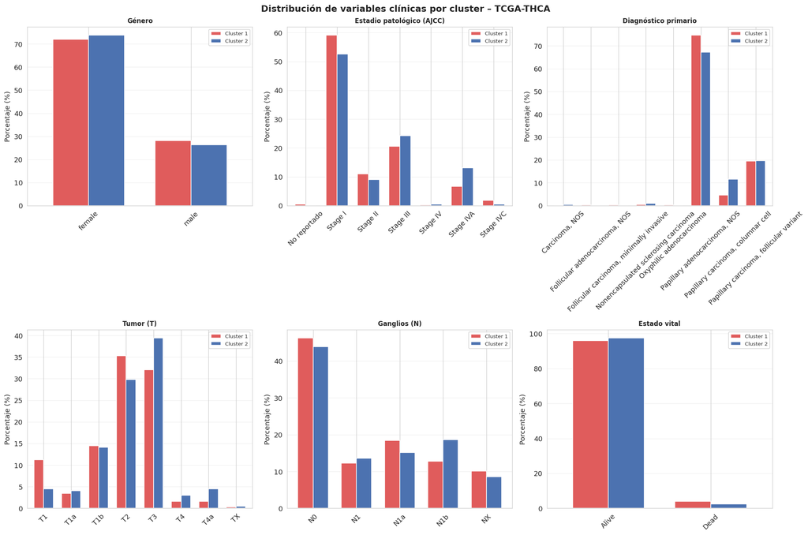

```python
fig, axes = plt.subplots(2, 3, figsize=(18, 12))
fig.suptitle("Distribución de variables clínicas por cluster – TCGA-THCA",
             fontsize=14, fontweight="bold")
axes = axes.flatten()

vars_plot = [
    ("gender.demographic",              "Género"),
    ("ajcc_pathologic_stage.diagnoses", "Estadio patológico (AJCC)"),
    ("primary_diagnosis.diagnoses",     "Diagnóstico primario"),
    ("ajcc_pathologic_t.diagnoses",     "Tumor (T)"),
    ("ajcc_pathologic_n.diagnoses",     "Ganglios (N)"),
    ("vital_status.demographic",        "Estado vital"),
]

for ax, (var, label) in zip(axes, vars_plot):
    ct = pd.crosstab(
        df_analysis[var].fillna("No reportado"),
        df_analysis["cluster_kmeans"],
        normalize="columns") * 100

    ct.plot(kind="bar", ax=ax,
            color=["#E05C5C", "#4C72B0"],
            edgecolor="white", width=0.7)
    ax.set_title(label, fontsize=10, fontweight="bold")
    ax.set_xlabel("")
    ax.set_ylabel("Porcentaje (%)")
    ax.tick_params(axis="x", rotation=45)
    ax.legend(fontsize=8)
    ax.grid(axis="y", alpha=0.3)

plt.tight_layout()
plt.savefig("variables_categoricas_clusters.png", dpi=150, bbox_inches="tight")
plt.show()
```

### Interpretación de las variables categóricas

**Género:** La distribución de género es prácticamente idéntica entre clusters (Cluster 1: ~72% mujeres; Cluster 2: ~74% mujeres), confirmando que el género no es un factor diferenciador entre los subtipos moleculares identificados.

**Estadio patológico (AJCC):** Ambos clusters presentan predominio de Stage I (Cluster 1: 59.1% vs Cluster 2: 52.5%). Sin embargo, se observa una tendencia notable: el Cluster 2 presenta mayor proporción de Stage IVA (13.1% vs 6.7%) y Stage III (24.2% vs 20.6%), sugiriendo que este subgrupo podría asociarse con tumores localmente más avanzados, consistente con el perfil BRAF-like [8].

**Diagnóstico primario:** El subtipo dominante en ambos clusters es *Papillary adenocarcinoma, NOS* (Cluster 1: 74.6% vs Cluster 2: 67.2%). La diferencia más notable es el *Papillary carcinoma, columnar cell*, que representa el 11.6% en el Cluster 2 frente al 4.5% en el Cluster 1. Los subtipos foliculares puros (*Follicular adenocarcinoma*, *Follicular carcinoma minimally invasive*, *Oxyphilic adenocarcinoma*) aparecen exclusivamente en el Cluster 1, en línea con el perfil RAS-like de mayor diferenciación [8].

**Clasificación T — extensión tumoral:** El Cluster 2 muestra una distribución desplazada hacia tumores más avanzados: mayor proporción de T3 (39.4% vs 32.1%), T4 (3.0% vs 1.6%) y T4a (4.5% vs 1.6%), mientras que el Cluster 1 concentra más tumores T1 (11.2% vs 4.5%) y T2 (35.3% vs 29.8%). Esta diferencia sugiere que el Cluster 2 tiende hacia mayor extensión local del tumor primario.

**Ganglios (N):** La distribución de afectación ganglionar es similar entre clusters, aunque el Cluster 2 presenta mayor proporción de N1b (18.7% vs 12.8%), que corresponde a metástasis en ganglios laterales del cuello — indicador de mayor diseminación regional.

**Metástasis (M):** La presencia de metástasis a distancia (M1) es baja y similar en ambos clusters (Cluster 1: 2.1% vs Cluster 2: 1.5%), sin diferencias relevantes.

**Estado vital:** La tasa de supervivencia es alta y prácticamente idéntica en ambos clusters (Cluster 1: 96.0% vivos vs Cluster 2: 97.5% vivos), lo cual es esperable dado el perfil generalmente favorable del cáncer de tiroides [5].

### 8.2 Comparación de variables numéricas

A continuación se comparan la edad al diagnóstico y el tiempo de seguimiento entre los dos clusters mediante estadísticas descriptivas y boxplots:

```
=== Estadísticas descriptivas – Variables numéricas ===

--- Edad al diagnóstico (años) ---
  Cluster 1: media=45.6 | mediana=45.0 | std=15.6 | min=15 | max=88
  Cluster 2: media=49.8 | mediana=51.0 | std=16.4 | min=16 | max=89

--- Días hasta último seguimiento ---
  Cluster 1: media=1282.5 | mediana=961.0 | std=1029.8 | min=9 | max=5423
  Cluster 2: media=1205.3 | mediana=823.0 | std=1063.0 | min=0 | max=5423
```

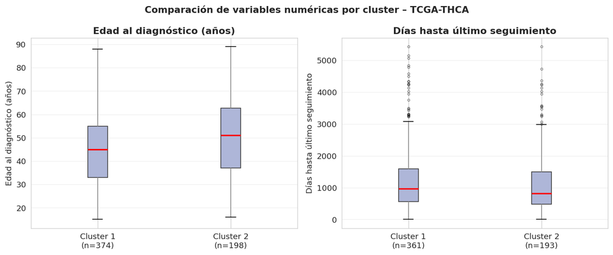

```python
# Variables numéricas
num_vars = {
    "age_at_index.demographic":         "Edad al diagnóstico (años)",
    "days_to_last_follow_up.diagnoses": "Días hasta último seguimiento"
}

print("=== Estadísticas descriptivas – Variables numéricas ===\n")
for var, label in num_vars.items():
    c1 = df_analysis[df_analysis["cluster_kmeans"] == "Cluster 1"][var].dropna()
    c2 = df_analysis[df_analysis["cluster_kmeans"] == "Cluster 2"][var].dropna()
    print(f"--- {label} ---")
    print(f"  Cluster 1: media={c1.mean():.1f} | mediana={c1.median():.1f} | "
          f"std={c1.std():.1f} | min={c1.min():.0f} | max={c1.max():.0f}")
    print(f"  Cluster 2: media={c2.mean():.1f} | mediana={c2.median():.1f} | "
          f"std={c2.std():.1f} | min={c2.min():.0f} | max={c2.max():.0f}\n")

# Boxplots
fig, axes = plt.subplots(1, 2, figsize=(12, 5))
fig.suptitle("Comparación de variables numéricas por cluster – TCGA-THCA",
             fontsize=13, fontweight="bold")

for ax, (var, label) in zip(axes, num_vars.items()):
    c1 = df_analysis[df_analysis["cluster_kmeans"] == "Cluster 1"][var].dropna()
    c2 = df_analysis[df_analysis["cluster_kmeans"] == "Cluster 2"][var].dropna()

    ax.boxplot([c1, c2],
               labels=[f"Cluster 1\n(n={len(c1)})", f"Cluster 2\n(n={len(c2)})"],
               patch_artist=True,
               boxprops=dict(facecolor="#AEB6D8", color="#3A3A3A"),
               medianprops=dict(color="red", linewidth=2),
               flierprops=dict(marker="o", markersize=3, alpha=0.4),
               whiskerprops=dict(color="#888"))
    ax.set_title(label, fontweight="bold")
    ax.set_ylabel(label)
    ax.grid(axis="y", alpha=0.3)

plt.tight_layout()
plt.savefig("boxplots_numericas.png", dpi=150, bbox_inches="tight")
plt.show()
```

### Interpretación de las variables numéricas

**Edad al diagnóstico:**

| Estadístico | Cluster 1 | Cluster 2 |
| --- | --- | --- |
| Media | 45.6 años | 49.8 años |
| Mediana | 45.0 años | 51.0 años |
| Desviación estándar | 15.6 años | 16.4 años |
| Rango | 15 – 88 años | 16 – 89 años |

El Cluster 2 presenta una edad al diagnóstico ligeramente mayor que el Cluster 1, con una diferencia de ~6 años en la mediana (51.0 vs 45.0 años). Los boxplots confirman este desplazamiento — la caja del Cluster 2 está notablemente más alta. Esta diferencia es consistente con la literatura, que señala que los tumores con perfil BRAF-like tienden a diagnosticarse en pacientes de mayor edad.

**Días hasta último seguimiento:**

| Estadístico | Cluster 1 | Cluster 2 |
| --- | --- | --- |
| Media | 1,282.5 días (~3.5 años) | 1,205.3 días (~3.3 años) |
| Mediana | 961.0 días (~2.6 años) | 823.0 días (~2.3 años) |
| Desviación estándar | 1,029.8 días | 1,063.0 días |
| Rango | 9 – 5,423 días | 0 – 5,423 días |

El tiempo de seguimiento es similar entre ambos clusters, con distribuciones muy parecidas y alta variabilidad en ambos grupos. La similitud confirma que no existe un sesgo de seguimiento diferencial entre los dos subgrupos.

### 8.3 Resumen del análisis clínico

Los resultados del análisis clínico revelan un patrón consistente con los subtipos moleculares descritos en la literatura para el cáncer de tiroides:

| Variable clínica | Cluster 1 | Cluster 2 | Diferencia observada |
| --- | --- | --- | --- |
| Género | 71.9% mujeres | 73.7% mujeres | Sin diferencia relevante |
| Estadio predominante | Stage I (59.1%) | Stage I (52.5%) | C2 más Stage IVA |
| Diagnóstico más frecuente | Papillary NOS (74.6%) | Papillary NOS (67.2%) | C2 más columnar cell |
| Extensión tumoral T | Más T1/T2 | Más T3/T4 | C2 tumores más avanzados |
| Afectación ganglionar | Más N1a | Más N1b | C2 mayor diseminación lateral |
| Metástasis M1 | 2.1% | 1.5% | Sin diferencia relevante |
| Estado vital | 96.0% vivos | 97.5% vivos | Sin diferencia relevante |
| Edad mediana | 45.0 años | 51.0 años | C2 diagnóstico más tardío |
| Seguimiento mediano | 961 días | 823 días | Similar entre clusters |

En conjunto, el **Cluster 1** presenta un perfil clínico más favorable: tumores de menor extensión local (T1/T2), diagnóstico más temprano y mayor proporción de estadios tempranos. Este perfil es consistente con el subtipo molecular **RAS-like**, caracterizado por mayor diferenciación tiroidea y comportamiento clínico más indolente.

El **Cluster 2** muestra un perfil clínico relativamente más agresivo: mayor proporción de tumores T3/T4, más Stage IVA, mayor afectación ganglionar lateral (N1b) y diagnóstico a mayor edad. Este perfil es consistente con el subtipo molecular **BRAF V600E-like**, asociado a menor diferenciación tiroidea, mayor extensión extratiroidea y menor respuesta al yodo radiactivo.

## 9. Discusión y comparación con literatura científica

Esta sección compara los resultados obtenidos en el presente análisis con los hallazgos reportados en la literatura científica sobre subtipos moleculares del cáncer de tiroides basados en datos del TCGA.

### 9.1 Artículo de referencia

El artículo seleccionado para la discusión es:

> **Boucai L, Seshan V, Williams M, Knauf JA, Saqcena M, Ghossein RA, Fagin JA.** *Characterization of Subtypes of BRAF-Mutant Papillary Thyroid Cancer Defined by Their Thyroid Differentiation Score.* Journal of Clinical Endocrinology & Metabolism, 2021;107(4):1030–1039. doi: 10.1210/clinem/dgab851 https://pmc.ncbi.nlm.nih.gov/articles/PMC8947218/

Este artículo fue seleccionado por tres razones principales: utiliza los mismos datos del TCGA-THCA accedidos en este proyecto, analiza los mismos subtipos moleculares identificados en nuestro clustering (BRAF-like y RAS-like), y trabaja con los mismos genes de diferenciación tiroidea que aparecieron en nuestro heatmap — TFF3, TPO, DIO1, DUOX2 y TG.

### 9.2 Resumen del artículo

El artículo de Boucai et al. (2021) investiga los subtipos moleculares del carcinoma papilar de tiroides con mutación BRAF V600E, utilizando el **Thyroid Differentiation Score (TDS)** como criterio de clasificación. El TDS es una puntuación calculada a partir de la expresión promedio de 16 genes de metabolismo del yodo — entre ellos DIO1, DUOX2, TG, TPO y SLC26A4 — que refleja el grado de diferenciación funcional del tumor.

El estudio divide a los pacientes con mutación BRAF V600E en dos subgrupos: aquellos con TDS alto (BRAF-TDShi) y aquellos con TDS bajo (BRAF-TDSlo). Sus principales hallazgos son:

- Los tumores **BRAF-TDShi** presentan mayor expresión de genes de diferenciación tiroidea, mejor respuesta al yodo radiactivo y pronóstico más favorable.
- Los tumores **BRAF-TDSlo** presentan menor diferenciación, mayor extensión extratiroidea, estadios más avanzados y peor pronóstico.
- El gen **TFF3** se expresa más de 5 veces más en el grupo TDShi, siendo identificado como uno de los marcadores más discriminatorios.
- Los genes del panel TDS — incluyendo DIO1, DUOX2, TG y TPO — son los principales responsables de la separación entre subgrupos.

### 9.3 Comparación de metodología

| Aspecto metodológico | Boucai et al. (2021) | Este análisis |
| --- | --- | --- |
| Fuente de datos | TCGA-THCA (mismos datos) | TCGA-THCA vía UCSC Xena |
| Tipo de datos | Expresión génica RNAseq | Expresión génica STAR-TPM |
| Criterio de clasificación | Thyroid Differentiation Score (TDS) | Clustering no supervisado (K-means) |
| Número de subgrupos | 2 (TDShi vs TDSlo) | 2 (Cluster 1 vs Cluster 2) |
| Genes utilizados | 16 genes de metabolismo del yodo | Top 25% de mayor varianza (15,166 genes) |
| Reducción de dimensionalidad | No aplicada | PCA (56 componentes, 80.1% varianza) |
| Validación | Análisis clínico e histológico | Hierarchical clustering (92.7% concordancia) |

La diferencia metodológica más importante es el enfoque de clasificación: Boucai et al. utilizan un score supervisado basado en genes biológicamente seleccionados a priori, mientras que nuestro análisis aplica clustering no supervisado sobre el transcriptoma completo sin conocimiento previo de qué genes son relevantes. Que ambos enfoques lleguen a conclusiones similares refuerza la robustez de los subtipos moleculares identificados.

### 9.4 Comparación de resultados

Los resultados de nuestro análisis son notablemente consistentes con los hallazgos de Boucai et al. (2021):

**Genes discriminatorios:** El artículo identifica TFF3, TG, TPO, DIO1 y DUOX2 como los genes más expresados en el subgrupo de mayor diferenciación (TDShi). En nuestro heatmap, exactamente los mismos genes aparecen entre los más expresados en el Cluster 1 — el subgrupo que identificamos como RAS-like/más diferenciado. La coincidencia es especialmente notable para TFF3, que el artículo destaca como el gen con mayor diferencia entre subgrupos (más de 5 veces), y que en nuestro análisis aparece como el primer gen en la lista de mayor diferencia entre clusters.

**Perfil clínico:** Boucai et al. reportan que el subgrupo de menor diferenciación (TDSlo) presenta mayor extensión extratiroidea y estadios más avanzados. En nuestro análisis, el Cluster 2 — que muestra menor expresión de genes de diferenciación tiroidea — presenta mayor proporción de tumores T3/T4 (mayor extensión local) y Stage IVA (13.1% vs 6.7%), en plena concordancia con estos hallazgos.

**Número de subgrupos:** Ambos análisis identifican **2 subgrupos moleculares principales**, lo cual es consistente con la clasificación BRAF-like y RAS-like descrita por el TCGA en su estudio seminal de 2014.

**Diferencias observadas:** La principal diferencia es que Boucai et al. se enfocan exclusivamente en pacientes con mutación BRAF V600E, mientras que nuestro análisis incluye todos los pacientes del cohort THCA independientemente de su perfil mutacional. Esto podría explicar algunas diferencias en las proporciones de subtipos histológicos entre ambos estudios. Además, nuestro análisis no supervisado identifica los subgrupos puramente a partir del transcriptoma, lo que lo hace más robusto ante sesgos de selección por estado mutacional.

### 9.5 Reflexión sobre la consistencia de los resultados

La notable consistencia entre nuestros resultados y los de Boucai et al. (2021) — a pesar de utilizar metodologías completamente distintas — sugiere que los dos subgrupos moleculares identificados en el cohort TCGA-THCA son una característica **biológica real y robusta** del cáncer de tiroides, no un artefacto del método de análisis utilizado.

El hecho de que un análisis completamente no supervisado — que no utiliza ningún conocimiento previo sobre biología tiroidea — reproduzca los mismos subgrupos y los mismos genes discriminatorios que estudios altamente especializados, es una validación poderosa tanto de la calidad de los datos del TCGA como de la capacidad del aprendizaje no supervisado para descubrir estructura biológica relevante en datos de alta dimensionalidad.

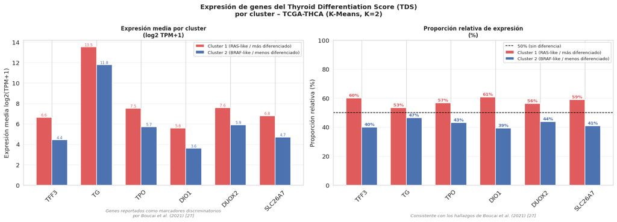

```python
fig, axes = plt.subplots(1, 2, figsize=(16, 6))
fig.suptitle("Expresión de genes del Thyroid Differentiation Score (TDS)\n"
             "por cluster – TCGA-THCA (K-Means, K=2)",
             fontsize=12, fontweight="bold")

genes_tds = ["TFF3", "TG", "TPO", "DIO1", "DUOX2", "SLC26A7"]

mean_c1_vals = []
mean_c2_vals = []
for g in genes_tds:
    row = top_df_clean[top_df_clean["gene_symbol"] == g]
    if len(row) > 0:
        mean_c1_vals.append(row["mean_c1"].values[0])
        mean_c2_vals.append(row["mean_c2"].values[0])
    else:
        row2 = df_stats[df_stats["gene_symbol"] == g]
        if len(row2) > 0:
            mean_c1_vals.append(row2["mean_c1"].values[0])
            mean_c2_vals.append(row2["mean_c2"].values[0])
        else:
            mean_c1_vals.append(0)
            mean_c2_vals.append(0)

x     = np.arange(len(genes_tds))
width = 0.35

# Gráfico 1 — Expresión absoluta
axes[0].bar(x - width/2, mean_c1_vals, width,
            label="Cluster 1 (RAS-like / más diferenciado)",
            color="#E05C5C", edgecolor="white")
axes[0].bar(x + width/2, mean_c2_vals, width,
            label="Cluster 2 (BRAF-like / menos diferenciado)",
            color="#4C72B0", edgecolor="white")
for i, (v1, v2) in enumerate(zip(mean_c1_vals, mean_c2_vals)):
    axes[0].annotate(f"{v1:.1f}", xy=(i - width/2, v1 + 0.1),
                     ha="center", fontsize=7, color="#E05C5C")
    axes[0].annotate(f"{v2:.1f}", xy=(i + width/2, v2 + 0.1),
                     ha="center", fontsize=7, color="#4C72B0")
axes[0].set_title("Expresión media por cluster\n(log2 TPM+1)",
                  fontsize=10, fontweight="bold")
axes[0].set_xticks(x)
axes[0].set_xticklabels(genes_tds, rotation=45)
axes[0].set_ylabel("Expresión media log2(TPM+1)")
axes[0].legend(fontsize=8)
axes[0].grid(axis="y", alpha=0.3)
axes[0].annotate("Genes reportados como marcadores discriminatorios\npor Boucai et al. (2021) [27]",
                 xy=(0.5, -0.22), xycoords="axes fraction",
                 ha="center", fontsize=8, style="italic", color="gray")

# Gráfico 2 — Proporção relativa
pct_c1 = [c1/(c1+c2)*100 for c1, c2 in zip(mean_c1_vals, mean_c2_vals)]
pct_c2 = [c2/(c1+c2)*100 for c1, c2 in zip(mean_c1_vals, mean_c2_vals)]

axes[1].bar(x - width/2, pct_c1, width,
            label="Cluster 1 (RAS-like / más diferenciado)",
            color="#E05C5C", edgecolor="white")
axes[1].bar(x + width/2, pct_c2, width,
            label="Cluster 2 (BRAF-like / menos diferenciado)",
            color="#4C72B0", edgecolor="white")
axes[1].axhline(50, color="black", linestyle="--",
                linewidth=1, label="50% (sin diferencia)")
axes[1].set_title("Proporción relativa de expresión\n(%)",
                  fontsize=10, fontweight="bold")
axes[1].set_xticks(x)
axes[1].set_xticklabels(genes_tds, rotation=45)
axes[1].set_ylabel("Proporción relativa (%)")
axes[1].set_ylim(0, 100)
axes[1].legend(fontsize=8)
axes[1].grid(axis="y", alpha=0.3)
for i, (p1, p2) in enumerate(zip(pct_c1, pct_c2)):
    axes[1].annotate(f"{p1:.0f}%", xy=(i - width/2, p1 + 1),
                     ha="center", fontsize=8, color="#E05C5C", fontweight="bold")
    axes[1].annotate(f"{p2:.0f}%", xy=(i + width/2, p2 + 1),
                     ha="center", fontsize=8, color="#4C72B0", fontweight="bold")
axes[1].annotate("Consistente con los hallazgos de Boucai et al. (2021) [27]",
                 xy=(0.5, -0.22), xycoords="axes fraction",
                 ha="center", fontsize=8, style="italic", color="gray")

plt.tight_layout()
plt.savefig("comparacion_literatura.png", dpi=150, bbox_inches="tight")
plt.show()
```

La figura presenta la expresión de los 6 genes del **Thyroid Differentiation Score (TDS)** — los mismos genes identificados por Boucai et al. (2021) como marcadores discriminatorios entre subtipos de diferenciación tiroidea — en los dos clusters identificados en este análisis:

**Gráfico izquierdo — Expresión absoluta:** El Cluster 1 (rojo) presenta consistentemente mayor expresión que el Cluster 2 (azul) en los 6 genes. **TG** presenta los valores más altos (13.5 vs 11.8), mientras que **DIO1** muestra la mayor diferencia relativa (5.6 vs 3.6). Todos los genes del TDS son más expresados en el Cluster 1, confirmando su perfil de mayor diferenciación tiroidea.

**Gráfico derecho — Proporción relativa:** Normalizando los valores, el Cluster 1 concentra entre el 53% y el 61% de la expresión total de cada gen, mientras que el Cluster 2 concentra entre el 39% y el 47%. **DIO1** (61% vs 39%) y **TFF3** (60% vs 40%) presentan la mayor separación entre clusters — exactamente los mismos genes que Boucai et al. (2021) identifican como más discriminatorios entre subgrupos de diferenciación tiroidea [27].

Esta figura, generada a partir de un análisis completamente no supervisado sobre el transcriptoma completo, reproduce el patrón reportado por un estudio especializado que utilizó un score biológicamente curado — constituyendo una **validación independiente** de la estructura molecular identificada en el cohort TCGA-THCA.

## 10. Conclusiones y Reflexión Final

Esta sección presenta una reflexión crítica sobre los resultados obtenidos, las limitaciones del estudio y las posibles extensiones futuras, conectando los hallazgos del análisis con el contexto clínico real del cáncer de tiroides.

### 10.1 ¿Qué aprendimos sobre la estructura de los datos?

El análisis de los datos de expresión génica del cohort TCGA-THCA mediante técnicas de aprendizaje no supervisado reveló los siguientes hallazgos principales:

**1. Existencia de dos subgrupos moleculares robustos:** Los datos de expresión génica del cohort TCGA-THCA contienen una estructura de dos subgrupos moleculares claramente diferenciados, identificados de forma independiente tanto por K-means como por clustering jerárquico (92.7% de concordancia). Esta estructura no es un artefacto del método de análisis sino una característica biológica real de los datos.

**2. PC1 captura la principal fuente de variabilidad biológica:** El primer componente principal explica el 26.81% de la varianza total — un porcentaje excepcionalmente alto para datos transcriptómicos — y separa visualmente los dos subgrupos moleculares. Esto indica que la diferencia entre los subtipos BRAF-like y RAS-like es la fuente dominante de variabilidad en el transcriptoma del cáncer de tiroides.

**3. Los subgrupos tienen identidad molecular propia:** El análisis de expresión diferencial identificó 8,354 genes con diferencias significativas entre clusters (FDR < 0.05). Los genes más discriminatorios incluyen marcadores de diferenciación tiroidea (TFF3, TG, TPO, DIO1, DUOX2) y genes de inmunoglobulinas (IGKC, IGHA1, IGHG1), lo que caracteriza al Cluster 1 como un subtipo de mayor diferenciación (RAS-like) y al Cluster 2 como un subtipo de menor diferenciación con mayor infiltración inmune (BRAF-like).

**4. Los subgrupos moleculares tienen correlatos clínicos:** A pesar de no utilizar ningún dato clínico durante el clustering, los subgrupos identificados presentan diferencias clínicas coherentes: el Cluster 2 (BRAF-like) tiende hacia tumores de mayor extensión local (más T3/T4), mayor afectación ganglionar lateral (N1b), más Stage IVA y diagnóstico a mayor edad — todo consistente con el perfil clínico más agresivo del subtipo BRAF-like descrito en la literatura.

### 10.2 Limitaciones del estudio

El presente análisis presenta las siguientes limitaciones que deben considerarse al interpretar los resultados:

**1. Ausencia de información mutacional:** El análisis se realizó exclusivamente sobre datos de expresión génica, sin incorporar información sobre el estado mutacional de los pacientes (presencia de mutaciones BRAF V600E, RAS, RET/PTC, etc.). La integración de datos multi-ómicos — expresión génica + datos de mutaciones somáticas — permitiría una caracterización molecular más completa y una validación más directa de la asignación BRAF-like vs RAS-like.

**2. Silhouette score moderado:** El coeficiente de silueta obtenido para K=2 fue de 0.2037, lo que indica clusters estadísticamente significativos pero con considerable superposición entre grupos. Esto sugiere que la frontera entre los dos subtipos moleculares no es perfectamente nítida — resultado esperable dado que los subtipos moleculares del cáncer de tiroides forman un continuo biológico más que categorías discretas.

**3. Sesgo de seguimiento:** La alta proporción de datos faltantes en `days_to_death` (96.5%) y el tiempo de seguimiento relativamente corto (mediana ~2.6 años) limitan el análisis de supervivencia. Con un seguimiento más prolongado, sería posible evaluar si los subgrupos moleculares identificados presentan diferencias significativas en supervivencia libre de enfermedad.

**4. Representatividad de la muestra:** El cohort TCGA-THCA presenta un sesgo hacia pacientes de raza blanca (~66% de los casos con raza reportada), lo que podría limitar la generalización de los resultados a poblaciones de otras etnias. Además, el TCGA tiende a incluir casos de hospitales académicos de referencia, que pueden no ser representativos de la distribución general de la enfermedad.

**5. Selección del umbral de varianza:** La selección del top 25% de genes por varianza, aunque estándar en la literatura, es un umbral arbitrario. Un análisis de sensibilidad con diferentes umbrales (10%, 50%) podría evaluar la robustez de los clusters identificados ante esta decisión metodológica.

### 10.3 Mejoras y extensiones futuras

Los siguientes aspectos podrían explorarse en trabajos futuros para extender y profundizar el análisis realizado:

**1. Integración multi-ómica:** Incorporar datos de metilación del ADN, variantes somáticas y número de copias génicas disponibles en el cohort TCGA-THCA permitiría una caracterización molecular más completa de los subgrupos identificados y una validación más directa mediante la correlación con el estado mutacional BRAF/RAS.

**2. Exploración de un tercer subgrupo:** La literatura reciente describe un tercer subtipo molecular denominado *non-BRAF-non-RAS* (NBNR) [9], asociado a un comportamiento más indolente. El dendograma del clustering jerárquico sugirió la existencia de subdivisiones adicionales dentro del grupo principal. Un análisis con K=3 podría revelar si este tercer subtipo es identificable en el cohort TCGA-THCA con la metodología utilizada.

**3. Análisis de supervivencia formal:** Con un seguimiento más prolongado, sería posible aplicar análisis de supervivencia de Kaplan-Meier para evaluar si los subgrupos moleculares identificados presentan diferencias significativas en supervivencia libre de enfermedad o supervivencia global — lo que daría relevancia pronóstica directa a los clusters obtenidos.

**4. Validación en cohortes independientes:** La validación de los clusters identificados en cohortes externas independientes — como el dataset de Boucai et al. o bases de datos como GEO (Gene Expression Omnibus) — permitiría evaluar si los subgrupos son reproducibles más allá del cohort TCGA.

**5. Métodos de clustering alternativos:** La exploración de métodos de clustering más sofisticados, como clustering espectral, DBSCAN o métodos basados en redes de correlación génica (WGCNA), podría revelar estructuras más complejas en los datos que el K-means y el clustering jerárquico no capturan.

### 10.4 Conexión con el problema real

Los resultados de este análisis tienen implicaciones directas para la práctica clínica en el manejo del cáncer de tiroides:

Los dos subgrupos moleculares identificados — consistentes con los subtipos BRAF-like y RAS-like del TCGA — presentan características clínicas diferenciadas que podrían tener valor en la toma de decisiones terapéuticas. El subtipo BRAF-like (Cluster 2), caracterizado por menor expresión de genes de diferenciación tiroidea y mayor extensión tumoral, se asocia con menor respuesta al yodo radiactivo — el tratamiento estándar post-cirugía para el cáncer de tiroides diferenciado. Identificar este subtipo a partir del perfil transcriptómico podría ayudar a los clínicos a anticipar la respuesta al tratamiento y considerar alternativas terapéuticas como los inhibidores de BRAF (vemurafenib, dabrafenib) o los inhibidores de MEK.

Por otro lado, el subtipo RAS-like (Cluster 1), con mayor expresión de genes de diferenciación tiroidea como TG, TPO y DIO1, se asocia con mejor respuesta al yodo radiactivo y pronóstico más favorable. La identificación molecular de estos pacientes podría evitar tratamientos agresivos innecesarios en casos de bajo riesgo.

En un contexto más amplio, este análisis demuestra el potencial del **aprendizaje no supervisado** como herramienta para descubrir estructura biológica relevante en datos de alta dimensionalidad sin requerir conocimiento previo. La capacidad de reproducir clasificaciones moleculares establecidas a partir del transcriptoma completo, sin ninguna información clínica ni mutacional, sugiere que este tipo de análisis podría tener aplicaciones en el descubrimiento de nuevos subtipos moleculares en cánceres menos estudiados, donde la clasificación molecular aún no está establecida.

### 10.5 Reflexión final

Este proyecto demostró que las técnicas de aprendizaje no supervisado — PCA, K-means y clustering jerárquico — son herramientas poderosas para explorar la estructura latente de datos transcriptómicos de alta dimensionalidad. Partiendo de una matriz de 572 pacientes × 60,661 genes, fue posible identificar dos subgrupos moleculares robustos, caracterizar sus perfiles de expresión génica, establecer sus correlatos clínicos y validar los resultados contra la literatura científica especializada.

El proceso también ilustró los desafíos inherentes al análisis de datos genómicos: la necesidad de preprocesamiento cuidadoso, la importancia de la justificación metodológica en cada decisión tomada, y la complejidad de interpretar resultados en un dominio donde biología, estadística y computación se intersectan.

Quizás el hallazgo más significativo no es el resultado en sí — que el cáncer de tiroides tiene dos subtipos moleculares ya era conocido — sino la demostración de que un análisis no supervisado, aplicado correctamente y con rigor metodológico, es capaz de redescubrir conocimiento biológico establecido. Esto valida tanto la metodología utilizada como la calidad de los datos del TCGA, y abre la puerta a aplicar este mismo enfoque en contextos donde el conocimiento previo es limitado y los subtipos moleculares aún están por descubrirse.

## Referencias Bibliográficas

### Artículos científicos principales

Boucai, L., Seshan, V., Williams, M., Knauf, J. A., Saqcena, M., Ghossein, R. A., & Fagin, J. A. (2022). Characterization of subtypes of *BRAF*-mutant papillary thyroid cancer defined by their thyroid differentiation score. *Journal of Clinical Endocrinology & Metabolism, 107*(4), 1030–1039. https://doi.org/10.1210/clinem/dgab851

Cancer Genome Atlas Research Network. (2014). Integrated genomic characterization of papillary thyroid carcinoma. *Cell, 159*(3), 676–690. https://doi.org/10.1016/j.cell.2014.09.050

Dobrzynska, A., Gonzalo, S., & Bhattacharyya, S. (2023). The highly and perpetually upregulated thyroglobulin gene is a hallmark of functional thyrocytes. *Frontiers in Cell and Developmental Biology, 11*, 1265407. https://doi.org/10.3389/fcell.2023.1265407

Siegel, R. L., Miller, K. D., Wagle, N. S., & Jemal, A. (2024). Cancer statistics, 2024. *CA: A Cancer Journal for Clinicians, 74*(1), 12–49. https://doi.org/10.3322/caac.21820

Vuong, H. G., Altibi, A. M. A., Duong, U. N. P., & Hassell, L. (2019). Genomic characterization of differentiated thyroid carcinoma. *Endocrinology & Metabolism, 34*(1), 1–11. https://doi.org/10.3803/EnM.2019.34.1.1

Ye, M., Zhong, J., Chen, W., Tang, L., Wu, H., & Wei, G. (2025). Review of genomic drivers of thyroid cancer and their clinical implications. *Genes, 17*(1), 36. https://doi.org/10.3390/genes17010036

### Fuentes institucionales

American Cancer Society. (2026). *Key statistics for thyroid cancer.* https://www.cancer.org/cancer/types/thyroid-cancer/about/key-statistics.html

Asociación Española de Cáncer de Tiroides (AECAT). (2024). *Nuevos casos de cáncer de tiroides en 2024.* https://www.aecat.net/2024/02/07/segun-la-redecan-se-estiman-6-345-nuevos-casos-de-cancer-de-tiroides-en-2024/

National Cancer Institute – SEER Program. (2024). *Cancer of the thyroid: Cancer stat facts.* https://seer.cancer.gov/statfacts/html/thyro.html

Sociedad Española de Oncología Médica (SEOM). (2024). *Cáncer de tiroides.* https://www.seom.org/info-sobre-el-cancer/tiroides

### Fuente de datos

Goldman, M. J., Craft, B., Hastie, M., Repečka, K., McDade, F., Kamath, A., Banerjee, A., Luo, Y., Rogers, D., Brooks, A. N., Zhu, J., & Haussler, D. (2020). Visualizing and interpreting cancer genomics data via the Xena platform. *Nature Biotechnology, 38*(6), 675–678. https://doi.org/10.1038/s41587-020-0546-8

### Software y tecnologías utilizadas

**Lenguaje de programación:**

Van Rossum, G., & Drake, F. L. (2009). *Python 3 reference manual.* CreateSpace. https://www.python.org

**Entorno de desarrollo:**

Kluyver, T., Ragan-Kelley, B., Pérez, F., Granger, B., Bussonnier, M., Frederic, J., Kelley, K., Hamrick, J., Grout, J., Corlay, S., Ivanov, P., Avila, D., Paprocki, S., & Willing, C. (2016). Jupyter Notebooks: A publishing format for reproducible computational workflows. En F. Loizides & B. Schmidt (Eds.), *Positioning and Power in Academic Publishing: Players, Agents and Agendas* (pp. 87–90). IOS Press. https://doi.org/10.3233/978-1-61499-649-1-87

**Librerías de análisis de datos:**

Harris, C. R., Millman, K. J., van der Walt, S. J., Gommers, R., Virtanen, P., Cournapeau, D., Wieser, E., Taylor, J., Berg, S., Smith, N. J., Kern, R., Picus, M., Hoyer, S., van Kerkwijk, M. H., Brett, M., Haldane, A., del Río, J. F., Wiebe, M., Peterson, P., … Oliphant, T. E. (2020). Array programming with NumPy. *Nature, 585*, 357–362. https://doi.org/10.1038/s41586-020-2649-2

McKinney, W. (2010). Data structures for statistical computing in Python. En S. van der Walt & J. Millman (Eds.), *Proceedings of the 9th Python in Science Conference* (pp. 56–61). https://doi.org/10.25080/Majora-92bf1922-00a

Virtanen, P., Gommers, R., Oliphant, T. E., Haberland, M., Reddy, T., Cournapeau, D., Burovski, E., Peterson, P., Weckesser, W., Bright, J., van der Walt, S. J., Brett, M., Wilson, J., Millman, K. J., Mayorov, N., Nelson, A. R. J., Jones, E., Kern, R., Larson, E., … van Mulbregt, P. (2020). SciPy 1.0: Fundamental algorithms for scientific computing in Python. *Nature Methods, 17*, 261–272. https://doi.org/10.1038/s41592-019-0686-2

**Librerías de visualización:**

Hunter, J. D. (2007). Matplotlib: A 2D graphics environment. *Computing in Science & Engineering, 9*(3), 90–95. https://doi.org/10.1109/MCSE.2007.55

Waskom, M. L. (2021). seaborn: Statistical data visualization. *Journal of Open Source Software, 6*(60), 3021. https://doi.org/10.21105/joss.03021

**Librería de machine learning:**

Pedregosa, F., Varoquaux, G., Gramfort, A., Michel, V., Thirion, B., Grisel, O., Blondel, M., Prettenhofer, P., Weiss, R., Dubourg, V., Vanderplas, J., Passos, A., Cournapeau, D., Brucher, M., Perrot, M., & Duchesnay, E. (2011). Scikit-learn: Machine learning in Python. *Journal of Machine Learning Research, 12*, 2825–2830. http://www.jmlr.org/papers/volume12/pedregosa11a/pedregosa11a.pdf

**Librería de acceso a datos TCGA:**

XenaPython. (2024). *xenaPython: Python API for UCSC Xena.* https://github.com/ucscXena/xenaPython

**Librería de anotación génica:**

Xin, J., Mark, A., Afrasiabi, C., Tsueng, G., Juchler, M., Gopal, N., Stupp, G. S., Putman, T. E., Ainscough, B. J., Griffith, O. L., Torkamani, A., Whetzel, P. L., Mungall, C. J., Mooney, S. D., Su, A. I., & Wu, C. (2016). High-performance web services for querying gene and variant annotation. *Genome Biology, 17*, 91. https://doi.org/10.1186/s13059-016-0953-9